# PBMC: Storage at 4ºC

Ramon Massoni-Badosa

10/21/2019

# 1 Introduction

The objective of this notebook is to assess if storing blood samples at 4ºC before cryopreservation yields better single-cell transcriptomes than storing them at room temperature (RT).

# 2 Pre-processing

## 2.1 Package loading

```r
library(scater)
library(scran)
library(Seurat)
library(ggpubr)
library(biomaRt)
library(org.Hs.eg.db)
library(AnnotationDbi)
library(GOplot)
library(GOstats)
library(kBET)
library(topGO)
library(ggrepel)
library(viridis)
library(pheatmap)
library(tidyverse)
```

## 2.2 Source script with functions

```r
source("bin/utils.R")
```

## 2.3 Load data

We dispose of a demultiplexed, filtered, normalized and annotated Seurat object that contains the transcriptome and metadata of >10,000 Peripheral Blood Mononuclear Cells (PBMC) from two donors (male/female) that were kept at varying times at RT (0h, 2h, 8h, 24h, 48h).

```r
pbmc <- readRDS("results/R_objects/10X_pbmc_Seurat_clustered.RDS")
pbmc_l <- readRDS("results/R_objects/10X_pbmc_Seurat_donors_list_clustered.RDS")
pbmc_l <- purrr::map(pbmc_l, function(seurat) {
  seurat$temperature <- case_when(
  seurat$condition %in% c("0h", "2h") ~ "fresh",
  seurat$condition %in% c("8h", "24h_RT", "48h_RT") ~ "RT",
  seurat$condition %in% c("24h_4C", "48h_4C") ~ "4ºC"
  )
  seurat$temperature <- factor(seurat$temperature, levels = c("fresh", "RT", "4ºC"))
  seurat$time <- str_remove(seurat$condition, pattern = "_4C|_RT")
  seurat
})
```

# 3 Visualize mixability

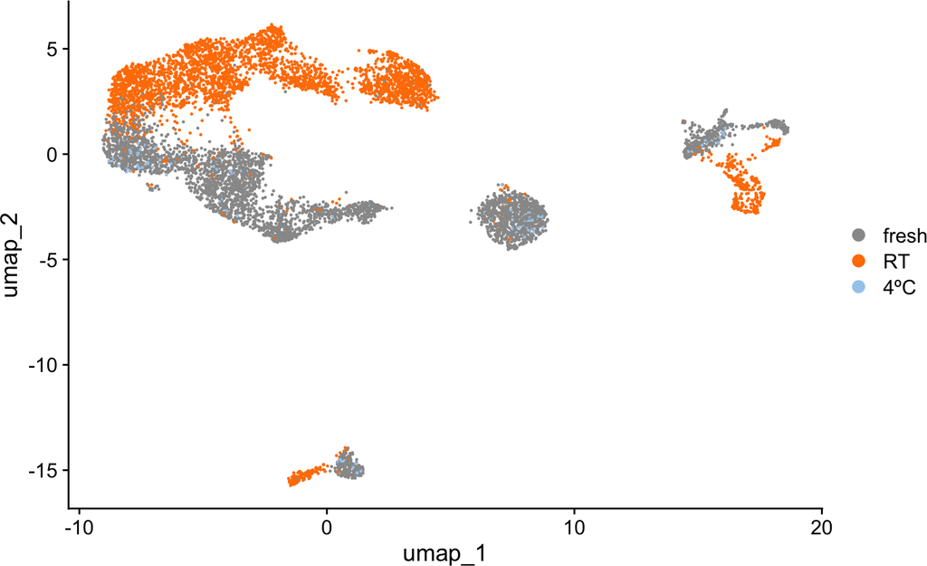

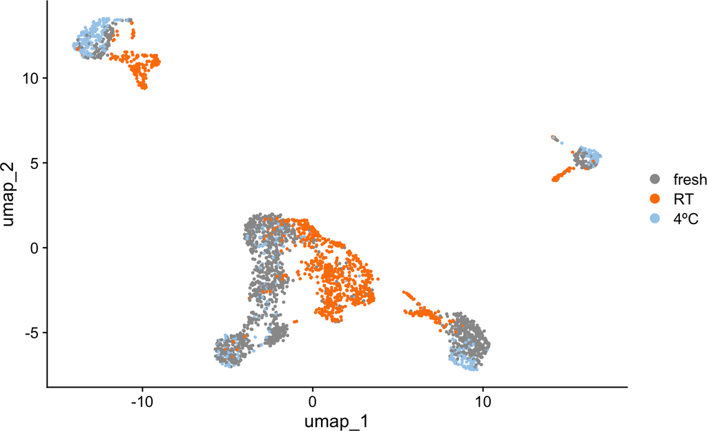

```r
# UMAP
umap_temperature <- purrr::map(pbmc_l, function(seurat) {
  Idents(seurat) <- "temperature"
  DimPlot(seurat, reduction = "umap", cols = c("#999999", "darkorange1", "#a5cded"))
})
umap_temperature
```

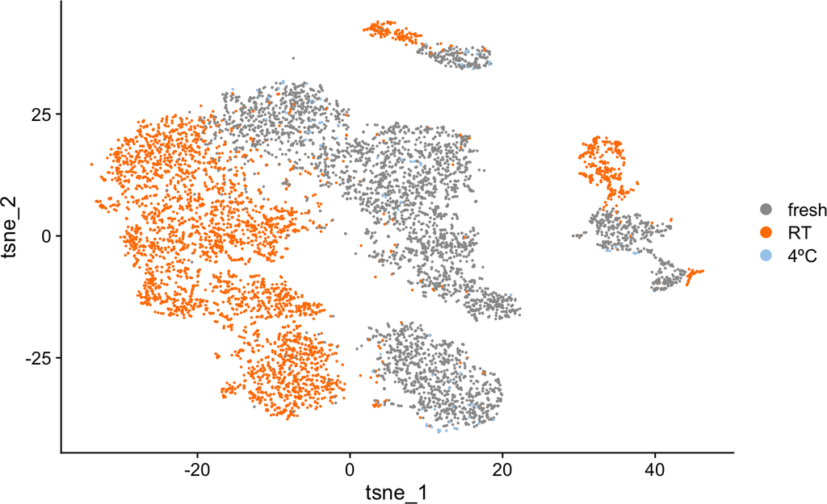

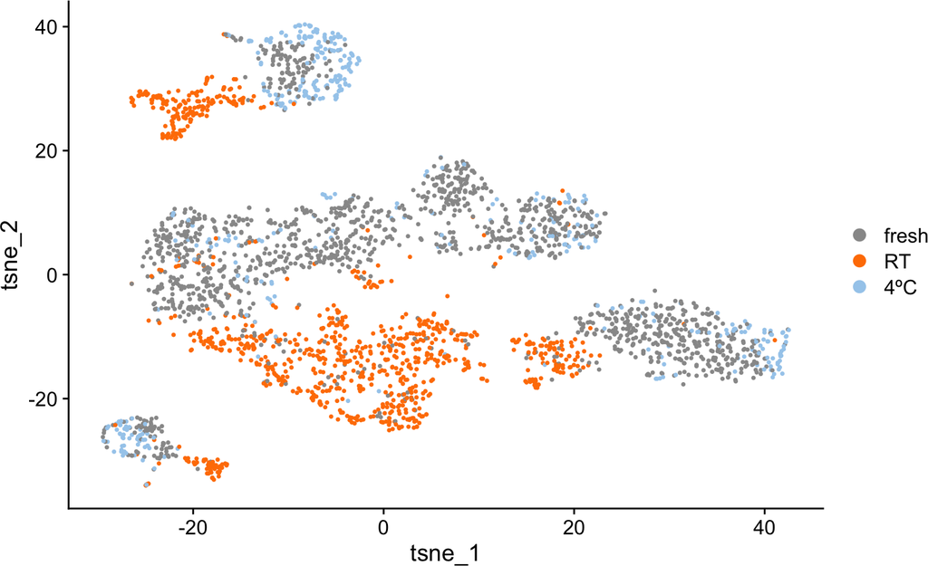

```r
# saveRDS(umap_temperature$female, "results/R_objects/ggplots/umap_4C_pbmc.rds")

# tSNE
tsne_temperature <- purrr::map(pbmc_l, function(seurat) {
  Idents(seurat) <- "temperature"
  DimPlot(seurat, reduction = "tsne", cols = c("#999999", "darkorange1", "#a5cded"))
})
tsne_temperature
```

```r
# saveRDS(tsne_temperature$female, "results/R_objects/ggplots/tsne_4C_pbmc.rds")
```

# 4 Quantify mixability (kBET)

Refer to previous notebooks to understand how kBET works.

```
## Initial neighbourhood size is set to 307.
## reducing dimensions with svd first...
## finding knns...done. Time:
##    user  system elapsed
##   0.329   0.009   0.403
## KNN input is a list, extracting nearest neighbour index.
```

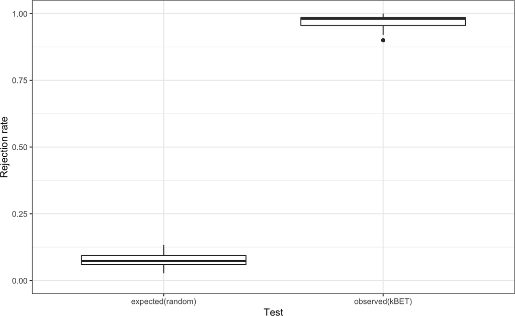

```
## Initial neighbourhood size is set to 244.
## reducing dimensions with svd first...
## finding knns...done. Time:
##    user  system elapsed
##   0.170   0.002   0.179
## KNN input is a list, extracting nearest neighbour index.
```

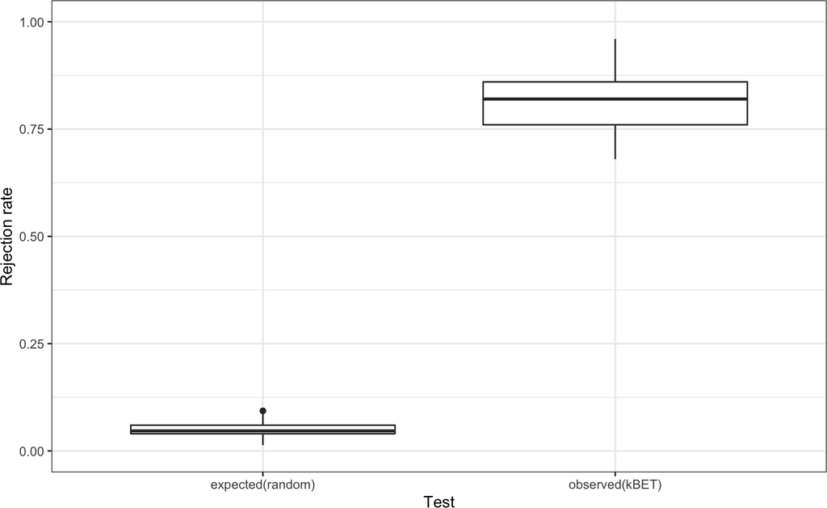

```r
pbmc_female <- pbmc_l$female
temperatures <- c("RT", "4ºC")
Idents(pbmc_female) <- "temperature"
acceptance_rate_dbl <- purrr::map_dbl(temperatures, function(temp) {
  seurat_sub <- subset(pbmc_female, idents = c("fresh", temp))
  seurat_sub$is_biased <- ifelse(seurat_sub$temperature == "fresh", FALSE, TRUE)
  mat <- as.matrix(seurat_sub@reductions$umap@cell.embeddings)
  batch <- seurat_sub$is_biased
  batch_estimate <- kBET(mat, batch = batch, verbose = TRUE, heuristic = FALSE, testSize = 50)
  batch_results <- batch_estimate$results
  batch_results <- batch_results %>%
    mutate(cell_type = seurat_sub$cell_type,
           time = seurat_sub$time) %>%
    filter(tested == 1) %>%
    summarise(acceptance_rate = mean(kBET.pvalue.test > 0.05) * 100)
  batch_results$acceptance_rate
})
```

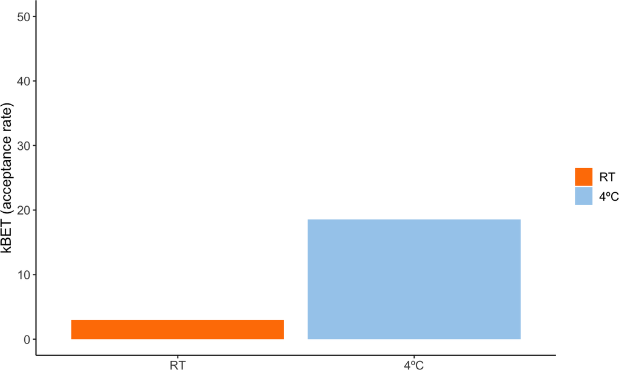

```r
acceptance_rate_df <- data.frame(
  temperature = temperatures,
  acceptance_rate = acceptance_rate_dbl
)

acceptance_rate_gg <- acceptance_rate_df %>%
  mutate(temperature = factor(temperature, levels = c("RT", "4ºC"))) %>%
  ggplot(aes(temperature, acceptance_rate, fill = temperature)) +
    geom_col(position = "dodge") +
    scale_y_continuous(limits = c(0, 50)) +
    scale_fill_manual(values = c("darkorange1", "#a5cded")) +
    labs(x = "", y = "kBET (acceptance rate)", fill = "") +
    theme_classic() +
    theme(axis.text = element_text(size = 11),
          axis.title.y = element_text(size = 13),
          legend.text = element_text(size = 11))
acceptance_rate_gg
```

```r
# saveRDS(
#   acceptance_rate_gg,
#   "results/R_objects/ggplots/barplot_acceptance_rate_storage_pbmc.rds"
# )
```

As we can see qualitatively (tSNEs) and quantitatively (kBET), storing at 4ºC partially prevents the sampling time biases on single-cell gene expression profiles.

# 5 Differential Expression Analysis

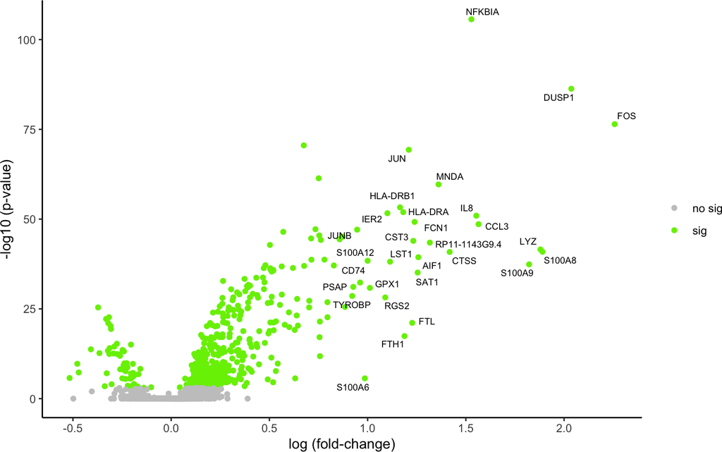

```r
Idents(pbmc_female) <- "temperature"
pbmc_f_sub <- subset(pbmc_female, idents = c("fresh", "4ºC"))
dea <- FindMarkers(pbmc_f_sub, ident.1 = "4ºC", test.use = "wilcox", logfc.threshold = 0)
dea <- rownames_to_column(dea, var = "gene")
dea <- dplyr::mutate(dea, significance = ifelse(p_val_adj < 0.001, "sig", "no sig"))
subset_data <- dplyr::filter(dea, avg_logFC > 0.9)
volcano <- dea %>%
  dplyr::mutate(significance = ifelse(p_val_adj < 0.001, "sig", "no sig")) %>%
  ggplot(aes(avg_logFC, -1 * log10(p_val_adj), color = significance)) +
    geom_point() +
    geom_text_repel(data = subset_data, aes(label = gene), color = "black", size = 2.5) +
    scale_color_manual(values = c("gray78", "chartreuse2")) +
    labs(x = "log (fold-change)", y = "-log10 (p-value)", color = "") +
    theme_classic()
volcano
```

```r
# saveRDS(volcano, "results/R_objects/ggplots/volcano_4ºC_pbmc.rds")
```

Overall, we detected a total of 521 differential expressed genes (DEG), 466 of which were upregulated and 55 were downregulated.

Among the up-regulated genes, we can find stress-related genes such as JUN, JUNB, FOS and NFKBIA. These genes have been related to other stresses, such as [collagenase-dependent tissue dissociation](https://www.nature.com/articles/nmeth.4437).